# Pratical Machine Learning

## Loading Data

```r
trainingDS  <- read.csv("C:/temp/data/pml-training.csv")
testingDS  <- read.csv("C:/temp/data/pml-testing.csv")
dim(trainingDS)
```

```
## [1] 19622   160
```

```r
dim(testingDS)
```

```
## [1]  20 160
```

## Cleaning Data

Firstly, variables with near zero variance are removed. There are 60 variables that fit this condition and an intermediary data frame of 100 variables is generated. Then, variables with more than 70% of NAs are removed. Final training data has 59 variables. From those, identifiers and timestamp variables are also removed make available only 53 variables to build prediction models.

```r
nzvstat <- nearZeroVar(trainingDS, saveMetrics=TRUE)
table(nzvstat$nzv)
```

```
##
## FALSE  TRUE
##   100    60
```

```r
trainingDS <- trainingDS[,nzvstat$nzv==FALSE]
dim(trainingDS)
```

```
## [1] 19622   100
```

```r
finalTrain <- trainingDS
for(i in 1:length(trainingDS)) {
    if( sum( is.na( trainingDS[, i] ) ) /nrow(trainingDS) >= .7) {
        for(j in 1:length(finalTrain)) {
            if( length( grep(names(trainingDS[i]), names(finalTrain)[j]) ) == 1)  {
                finalTrain <- finalTrain[ , -j]
            }
        }
    }
}
dim(finalTrain)
```

```
## [1] 19622    59
```

```r
finalTrain <- finalTrain[, -which(names(finalTrain) %in% c("X","user_name","raw_timestamp_part_1","raw_timestamp_part_2","cvtd_timestamp","num_window"))]
```

## Slicing Data

Now that main data manipulation tasks were applied in order to get a clean dataset, more efficient for training and with lower possibilites of inducting noise through sparsly filled variables, resulting data set is split in two sets. One for training (60% of overall training data) and a testing set with remaining data.

```r
classe <- finalTrain$classe
set.seed(123) # For reproducibile purpose
inTrain <- createDataPartition(finalTrain$classe, p=0.60, list=F)
trainData <- finalTrain[inTrain, ]
testData <- finalTrain[-inTrain, ]
dim(trainData)
```

```
## [1] 11776    53
```

```r
dim(testData)
```

```
## [1] 7846   53
```

## Predicting using Random Forest

```r
controlRf <- trainControl(method="cv", 5)
Rf <- train(classe ~ ., data=trainData, method="rf", trControl=controlRf, ntree=250)
Rf
```

```
## Random Forest
##
## 11776 samples
##    52 predictor
##     5 classes: 'A', 'B', 'C', 'D', 'E'
##
## No pre-processing
## Resampling: Cross-Validated (5 fold)
## Summary of sample sizes: 9422, 9421, 9420, 9421, 9420
## Resampling results across tuning parameters:
##
##   mtry  Accuracy   Kappa      Accuracy SD  Kappa SD
##    2    0.9887914  0.9858196  0.002822427  0.003572526
##   27    0.9887060  0.9857124  0.001659162  0.002100134
##   52    0.9833564  0.9789439  0.001879588  0.002380382
##
## Accuracy was used to select the optimal model using  the largest value.
## The final value used for the model was mtry = 2.
```

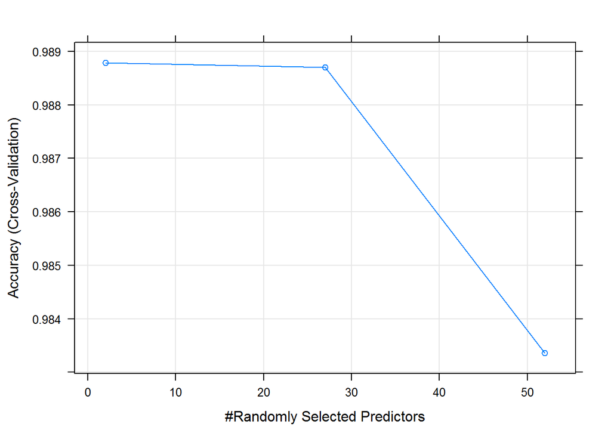

```r
plot(Rf)
```

## Predicting on the Test Data - out of Sample Error

When applying obtained Random Forest Model to test data we get an accuracy of nearly 100%, with an Out Of Sample Error as small as 0.9%.

```r
predTestData <- predict(Rf, testData)
confusionMatrix(testData$classe, predTestData)
```

```
## Confusion Matrix and Statistics
##
##           Reference
## Prediction    A    B    C    D    E
##          A 2226    4    0    1    1
##          B    8 1507    3    0    0
##          C    1   14 1350    3    0
##          D    0    0   26 1260    0
##          E    0    0    3    3 1436
##
## Overall Statistics
##
##                Accuracy : 0.9915
##                  95% CI : (0.9892, 0.9934)
##     No Information Rate : 0.2849
##     P-Value [Acc > NIR] : < 2.2e-16
##
##                   Kappa : 0.9892
##  Mcnemar's Test P-Value : NA
##
## Statistics by Class:
##
##                      Class: A Class: B Class: C Class: D Class: E
## Sensitivity            0.9960   0.9882   0.9768   0.9945   0.9993
## Specificity            0.9989   0.9983   0.9972   0.9960   0.9991
## Pos Pred Value         0.9973   0.9928   0.9868   0.9798   0.9958
## Neg Pred Value         0.9984   0.9972   0.9951   0.9989   0.9998
## Prevalence             0.2849   0.1944   0.1761   0.1615   0.1832
## Detection Rate         0.2837   0.1921   0.1721   0.1606   0.1830
## Detection Prevalence   0.2845   0.1935   0.1744   0.1639   0.1838
## Balanced Accuracy      0.9975   0.9932   0.9870   0.9953   0.9992
```

```r
accuracy <- postResample(predTestData, testData$classe)
accuracy
```

```
##  Accuracy     Kappa
## 0.9914606 0.9891978
```

```r
OutofSError <- 1 - as.numeric(confusionMatrix(testData$classe, predTestData)$overall[1])
OutofSError
```

```
## [1] 0.008539383
```

## Further Predition Models and visualization

A Decision Tree was built in order to make model results visable and explorable to user. This model provides a good starting point to help understand undisclosed business rules hidden on data. However its accuracy is around 77% much lower than 99% obtained with Random Forest.

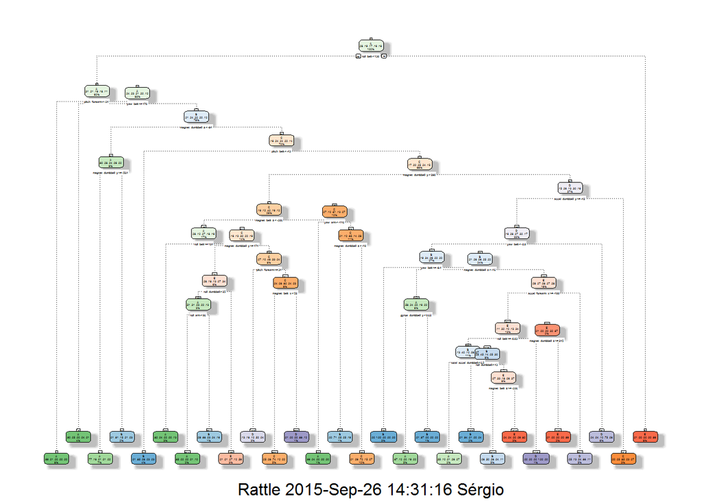

```r
Dt <- rpart(classe ~ ., data=trainData, method="class")
fancyRpartPlot(Dt)
```

```r
predTestData <- predict(Dt, testData, type = "class")
confusionMatrix(predTestData, testData$classe)
```

```
## Confusion Matrix and Statistics
##
##           Reference
## Prediction    A    B    C    D    E
##          A 2059  203   18  128   79
##          B   60 1086  211   70   93
##          C   20   83  998  184   83
##          D   71  138   81  863  120
##          E   22    8   60   41 1067
##
## Overall Statistics
##
##                Accuracy : 0.774
##                  95% CI : (0.7646, 0.7832)
##     No Information Rate : 0.2845
##     P-Value [Acc > NIR] : < 2.2e-16
##
##                   Kappa : 0.713
##  Mcnemar's Test P-Value : < 2.2e-16
##
## Statistics by Class:
##
##                      Class: A Class: B Class: C Class: D Class: E
## Sensitivity            0.9225   0.7154   0.7295   0.6711   0.7399
## Specificity            0.9238   0.9314   0.9429   0.9375   0.9795
## Pos Pred Value         0.8279   0.7145   0.7295   0.6779   0.8907
## Neg Pred Value         0.9677   0.9317   0.9429   0.9356   0.9436
## Prevalence             0.2845   0.1935   0.1744   0.1639   0.1838
## Detection Rate         0.2624   0.1384   0.1272   0.1100   0.1360
## Detection Prevalence   0.3170   0.1937   0.1744   0.1622   0.1527
## Balanced Accuracy      0.9231   0.8234   0.8362   0.8043   0.8597
```

## Test Data

Finally, provided testing data is structured aligned with data set used to train the Random Forest Model by removing not used columns. Then, predition is applied to it and results are written to results datasets to be uploaded to curera.

```r
testingDS <- testingDS[, which(names(testingDS) %in% colnames(finalTrain))]

result <- predict(Rf, testingDS)
result
```

```
##  [1] B A B A A E D B A A B C B A E E A B B B
## Levels: A B C D E
```

```r
pml_write_files = function(x){
  n = length(x)
  for(i in 1:n){
    filename = paste0("problem_id_",i,".txt")
    write.table(x[i],file=filename,quote=FALSE,row.names=FALSE,col.names=FALSE)
  }
}
pml_write_files(result)
```